# TF_期中期末

##### Check & Save

```r
is.na(Z) %>% colSums
```

```
##  date  cust   age  area   cat  prod   qty  cost price   tid
##     0     0     0     0     0     0     0     0     0     0
```

```r
is.na(X) %>% colSums
```

```
##    tid   date   cust    age   area  items pieces  total  gross
##      0      0      0      0      0      0      0      0      0
```

```r
is.na(A) %>% colSums
```

```
## cust    r    s    f    m  rev  raw  age area
##    0    0    0    0    0    0    0    0    0
```

```r
A0 = A; X0 = X; Z0 = Z
save(Z0, X0, A0, file="data/tf0.rdata")
```

### 4. 行銷企畫競賽

##### A.企畫項目

- 1)利用既有和衍生的變數做顧客分群(標籤)
- 2)根據顧客族群價值屬性，選取行銷重點、設定行銷目標
- 3)製作模型：估計每一位顧客的：
  - 回購機率
  - 預期營收、預期獲利
  - 終生價值
- 4)根據顧客族群特徵，設計(至少兩項)行銷方案
- 5)對方案的成本、效益進行(可以透過參數調整的)假設
- 6)設計模擬程式，藉以：
  - 選擇行銷方案
  - 設定方案參數
  - 選擇行銷對象
  - 估計成本效益
- 7)做一個完整的行銷企劃報告：
  - 經營現況
  - 改善策略
  - 行銷方案
  - 預期成效

##### B.評分項目

1. 能從資料中找出重要的現象、結構、趨勢
2. 能善用資料視覺化呈現重要發現
3. 能找出特殊的、有價值的顧客族群
4. 能找到或導出有預測力的變數
5. 能根據分析的結果選擇策略重點、設定策略(量化)目標
6. 能提出有效、有創意的行銷方案
7. 能設計出合理的假設
8. 能正確演練市場模擬的程序，清楚表達策略規劃的邏輯
9. 整份行銷企劃的整體(影片+文案)品質
10. 投入資源執行這一份企劃的意願

### 5. 資料探索練習

- 1)不同的年齡(或地理)族群的購買行為有什麼差異
- 2)顧客在周末和周間的購買行為是一樣的嗎
- 3)賣的最好的品類(品項)
- 4)銷售量或營收最大的品類(品項)獲利也是最大的嗎
- 5)依據 … 做顧客分群(市場區隔)
  - RFM
  - 年齡層、居住地區
  - 曾購買的產品
  - …
- 6)比較各族群的特徵
- 7)…
- 8)設定行銷目標和策略

##### 類別資料的分類統計

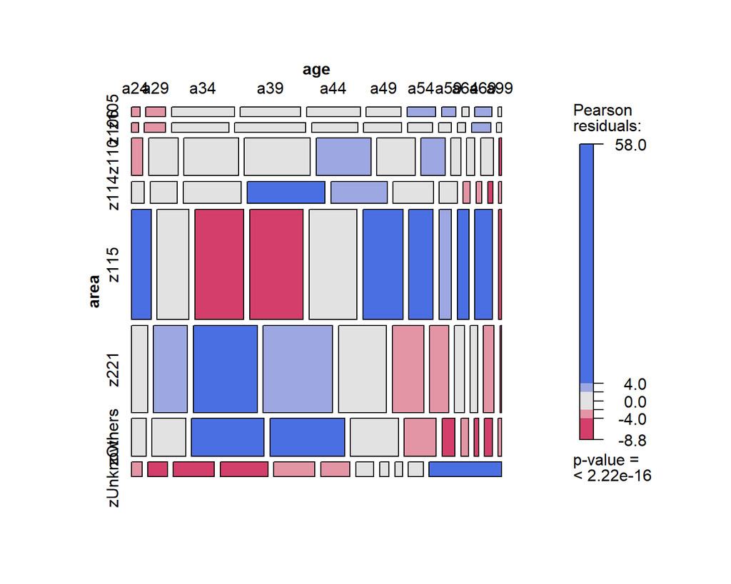

```r
mosaic(~area+age, data=A, shade=T)
```